# Homework 9

¶ ¶

¶ < JACOB FISHER > ¶

## Data and Description

See the attached data description.

#### 0. Replace the text “< PUT YOUR NAME HERE >” (above next to “author:”) with your full name.

#### 1. Read in the data set, and call the data frame `snow`. Make sure the core variable is a factor (if they are not, you’ll need to make them factors). Print a summary of the data and make sure the data makes sense.

```r
snow <- read.csv("snow_core.csv") %>%
  mutate(Core = as.factor(Core))
summary(snow)
```

```
##       Core          Depth          Density
##  3      :1128   Min.   : 0.00   Min.   :0.2290
##  13     :1008   1st Qu.: 4.32   1st Qu.:0.4752
##  11     : 899   Median : 8.66   Median :0.5345
##  7      : 895   Mean   : 8.78   Mean   :0.5163
##  5      : 893   3rd Qu.:13.00   3rd Qu.:0.5703
##  8      : 867   Max.   :22.54   Max.   :0.6705
##  (Other):6447
```

#### 2. What is your outcome? What is/are your explanatory variable(s)?

Density is the outcome variable with depth and core number as our explanatory variables.

#### 3. Fit a linear model using depth as a linear effect. Also, include an effect for core BUT NO INTERACTION.

```r
lm_snow <- lm(Density ~ Depth+Core ,data = snow)
lm_snow
```

```
##
## Call:
## lm(formula = Density ~ Depth + Core, data = snow)
##
## Coefficients:
## (Intercept)        Depth        Core2        Core3        Core4        Core5
##   0.4163200    0.0120798    0.0006071   -0.0189423   -0.0056777   -0.0116790
##       Core6        Core7        Core8        Core9       Core10       Core11
##  -0.0171403   -0.0030338   -0.0041327    0.0031216    0.0014737   -0.0016919
##      Core12       Core13       Core14
##  -0.0026773   -0.0138113   -0.0046774
```

#### 4. For this model, calculate the AIC.

```r
AIC(lm_snow)
```

```
## [1] -50348.49
```

#### 5. Fit a linear model using depth as a linear effect and an interaction with core. That is, a model with a line for each core. Use the predict function to save the model fit as `pred.linear` in the `snow` data frame. Save the residuals as `resid.linear` in the `snow` data frames. You will use these in problems 7 and 8.

```r
lm_cores <- lm(Density ~ Depth+Depth*Core ,data = snow)
lm_cores
```

```
##
## Call:
## lm(formula = Density ~ Depth + Depth * Core, data = snow)
##
## Coefficients:
##  (Intercept)         Depth         Core2         Core3         Core4
##    4.206e-01     1.152e-02    -9.106e-04     1.852e-02    -1.753e-02
##        Core5         Core6         Core7         Core8         Core9
##   -2.170e-02    -5.722e-02    -1.472e-02    -3.724e-03     6.825e-03
##       Core10        Core11        Core12        Core13        Core14
##   -1.355e-03     5.209e-04    -1.667e-02    -3.527e-02    -3.066e-02
##  Depth:Core2   Depth:Core3   Depth:Core4   Depth:Core5   Depth:Core6
##    1.982e-04    -3.153e-03     1.470e-03     1.194e-03     4.936e-03
##  Depth:Core7   Depth:Core8   Depth:Core9  Depth:Core10  Depth:Core11
##    1.378e-03     7.918e-06    -3.779e-04     3.804e-04    -1.735e-04
## Depth:Core12  Depth:Core13  Depth:Core14
##    1.707e-03     2.256e-03     3.767e-03
```

```r
snow$resid.linear<-resid((lm_cores))
```

#### 6. For this model, calculate the AIC.

```r
AIC(lm_cores)
```

```
## [1] -51851.09
```

#### 7. For the first site (Core = 1), plot the data and your model fit together.

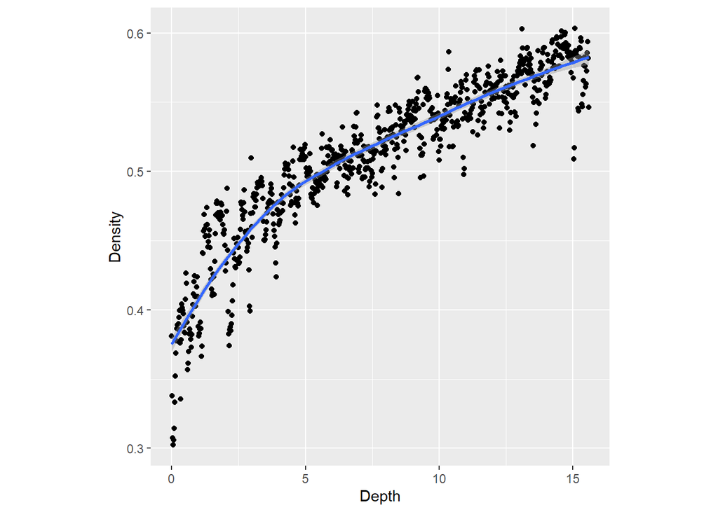

```r
ggplot(subset(snow, Core == 1), aes(x = Depth, y = Density)) +
  geom_point() +
  geom_smooth() +
  theme(aspect.ratio = 1)
```

#### 8. For the first site (Core = 1), plot the residuals against depth. Comment on the pattern.

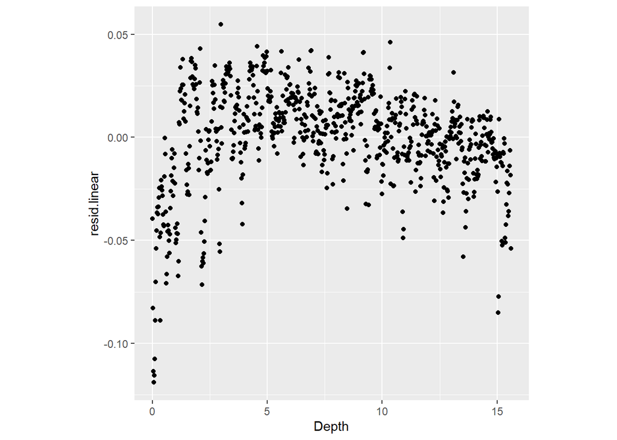

```r
# Create a scatter plot of residuals versus depth
ggplot(subset(snow, Core == 1), aes(x = Depth, y = resid.linear)) +
  geom_point() +
  theme(aspect.ratio = 1)
```

The residuals differ from zero more at the extremes and are more uniform towards the middle, though there is a seeming quadratic trend to the residuals.

#### 9. Fit a model using a cubic polynomial for depth. Also, include an effect for core BUT NO INTERACTION.

```r
lm_poly_cub = lm(Density ~ Depth + poly(Core,3),data = snow)
lm_poly_cub
```

```
##
## Call:
## lm(formula = Density ~ Depth + poly(Core, 3), data = snow)
##
## Coefficients:
##    (Intercept)           Depth  poly(Core, 3)1  poly(Core, 3)2  poly(Core, 3)3
##        0.41163         0.01193         0.10757        -0.01507        -0.48435
```

#### 10. For this model, calculate the AIC.

```r
AIC(lm_poly_cub)
```

```
## [1] -49999.52
```

#### 11. Fit a model using a cubic polynomial for depth and an interaction with core. That is, a model with a unique cubic polynomial for each core. Something like `lm(Density ~ Core * poly(Depth,3))`.

```r
lm_poly_cubcore<-lm(Density ~ Core * poly(Depth,3), data=snow)
lm_poly_cubcore
```

```
##
## Call:
## lm(formula = Density ~ Core * poly(Depth, 3), data = snow)
##
## Coefficients:
##            (Intercept)                   Core2                   Core3
##               0.522615               -0.002372               -0.006114
##                  Core4                   Core5                   Core6
##              -0.009084               -0.012279               -0.018886
##                  Core7                   Core8                   Core9
##              -0.003768               -0.003843                0.003308
##                 Core10                  Core11                  Core12
##               0.001585               -0.001048               -0.005146
##                 Core13                  Core14         poly(Depth, 3)1
##              -0.012816               -0.027209                6.856556
##        poly(Depth, 3)2         poly(Depth, 3)3   Core2:poly(Depth, 3)1
##              -0.363994                1.684281               -0.574869
##  Core3:poly(Depth, 3)1   Core4:poly(Depth, 3)1   Core5:poly(Depth, 3)1
##              -1.083914               -0.197791                0.319827
##  Core6:poly(Depth, 3)1   Core7:poly(Depth, 3)1   Core8:poly(Depth, 3)1
##               1.689941                0.397279               -0.109346
##  Core9:poly(Depth, 3)1  Core10:poly(Depth, 3)1  Core11:poly(Depth, 3)1
##              -0.330152                0.055844               -0.222309
## Core12:poly(Depth, 3)1  Core13:poly(Depth, 3)1  Core14:poly(Depth, 3)1
##               0.127955                1.770160               -3.307506
##  Core2:poly(Depth, 3)2   Core3:poly(Depth, 3)2   Core4:poly(Depth, 3)2
##              -1.051680               -1.399266               -1.821833
##  Core5:poly(Depth, 3)2   Core6:poly(Depth, 3)2   Core7:poly(Depth, 3)2
##              -1.370591               -1.946593               -1.430967
##  Core8:poly(Depth, 3)2   Core9:poly(Depth, 3)2  Core10:poly(Depth, 3)2
##              -1.005119               -1.061244               -1.344089
## Core11:poly(Depth, 3)2  Core12:poly(Depth, 3)2  Core13:poly(Depth, 3)2
##              -1.405378               -1.892769               -2.053382
## Core14:poly(Depth, 3)2   Core2:poly(Depth, 3)3   Core3:poly(Depth, 3)3
##              -5.294183               -0.772865               -1.148765
##  Core4:poly(Depth, 3)3   Core5:poly(Depth, 3)3   Core6:poly(Depth, 3)3
##              -1.781186               -1.534820               -1.813082
##  Core7:poly(Depth, 3)3   Core8:poly(Depth, 3)3   Core9:poly(Depth, 3)3
##              -1.709631               -0.106994                0.019275
## Core10:poly(Depth, 3)3  Core11:poly(Depth, 3)3  Core12:poly(Depth, 3)3
##               0.101054               -0.474902               -1.511324
## Core13:poly(Depth, 3)3  Core14:poly(Depth, 3)3
##              -0.845584               -3.893740
```

#### 12. For this model, calculate the AIC.

```r
AIC(lm_poly_cubcore)
```

```
## [1] -57519.7
```

#### 13. Fit a model using a cubic spline for depth. Place a knot at 10 meters depth. Also, include an effect for core BUT NO INTERACTION.

```r
lm_spline_cub = lm(Density ~ Core +
                      bs(Depth,knots = 10, degree = 3),
                    data = snow)
lm_spline_cub
```

```
##
## Call:
## lm(formula = Density ~ Core + bs(Depth, knots = 10, degree = 3),
##     data = snow)
##
## Coefficients:
##                        (Intercept)                               Core2
##                          3.641e-01                           7.668e-04
##                              Core3                               Core4
##                         -5.687e-03                          -4.753e-03
##                              Core5                               Core6
##                         -8.758e-03                          -1.636e-02
##                              Core7                               Core8
##                         -4.742e-05                          -2.017e-03
##                              Core9                              Core10
##                          5.091e-03                           3.386e-03
##                             Core11                              Core12
##                          1.426e-03                          -1.318e-03
##                             Core13                              Core14
##                         -6.484e-03                          -6.011e-03
## bs(Depth, knots = 10, degree = 3)1  bs(Depth, knots = 10, degree = 3)2
##                          1.102e-01                           2.100e-01
## bs(Depth, knots = 10, degree = 3)3  bs(Depth, knots = 10, degree = 3)4
##                          2.415e-01                           2.498e-01
```

#### 14. For this model, calculate the AIC.

```r
AIC(lm_spline_cub)
```

```
## [1] -55625.93
```

#### 15. Fit a model using depth as cubic spline for depth and an interaction with core. Again, place a knot at 10 meters depth. That is, a model with a unique cubic spline for each. Use the predict function to save the model fit as `pred.spline` in the `snow` data frame. Save the residuals as `resid.spline` in the `snow` data frames.

```r
lm_spline_cubint = lm(Density ~ Core + Core*Depth +
                      bs(Depth,knots = 10, degree = 3),
                    data = snow)
snow$pred.spline<-predict(lm_spline_cubint)
snow$resid.spline <- resid(lm_spline_cubint)
```

#### 16. For this model, calculate the AIC.

```r
AIC(lm_spline_cubint)
```

```
## [1] -57058.26
```

#### 17. For the first site (Core = 1), plot the data and your model fit together to verify that it is effectively capturing the snow density curve. This should be the cubic spline model with interactions.

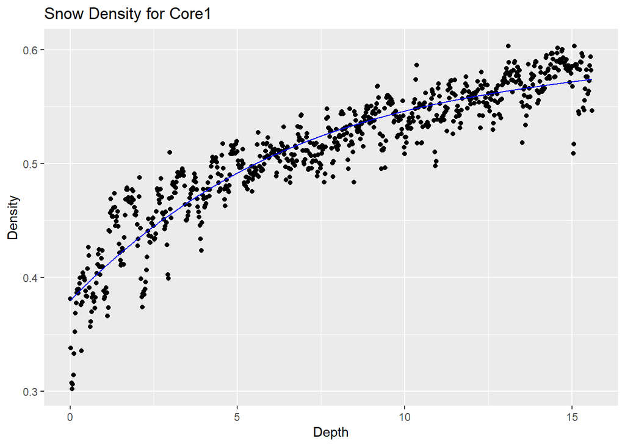

```r
ggplot(subset(snow, Core == 1), aes(x = Depth, y = Density)) +
  geom_point() +
  geom_line(aes(y = pred.spline), color = "blue") +
  labs(title = "Snow Density for Core1",
       x = "Depth",
       y = "Density")
```

#### 18. For the first site (Core = 1), plot the residuals of your model against depth. Comment on the pattern. This should be the cubic spline model with interactions.

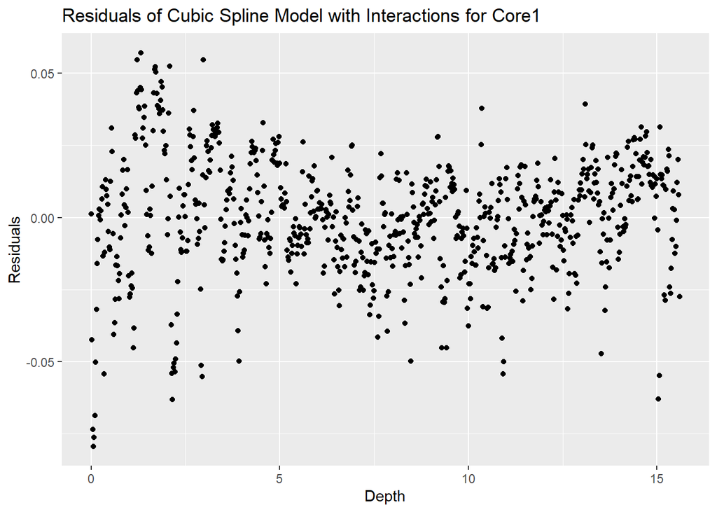

```r
ggplot(subset(snow, Core == 1), aes(x = Depth, y = resid.spline)) +
  geom_point() +
  labs(title = "Residuals of Cubic Spline Model with Interactions for Core1",
       x = "Depth",
       y = "Residuals")
```

#### 20. Briefly summarize what you learned, personally, from this analysis about the statistics, model fitting process, etc.

I gained a better understanding of different non-linear modeling and how to test the fit of each model. These models include splines and polynomial functions.